# Introduction to Python

- Python
  - What is Python?
  - Why should you know Python?
  - Where can I get it?
- Jupyter Notebook
  - What is Jupyter Notebook?
  - How to use it?
- Let's code
  - Introduction to Python
    - Numbers
    - Strings
    - Lists
    - While statements
    - If statements
    - For statements
    - Defining functions
  - Mathematics and Statistics packages
    - NumPy
    - pandas
    - Matplotlib
- Mini Challenge
- Assignment
- FAQs
- Learning Materials

# Python

## What is Python

Python is a programming language that lets you work quickly and integrate systems more effectively. It's simple, easy to learn syntax emphasizes readability and therefore reduces the cost of program maintenance. Python supports modules and packages, which encourages program modularity and code reuse. The Python interpreter and the extensive standard library are available in source or binary form without charge for all major platforms, and can be freely distributed. [Python.org](https://www.python.org/):

## Why should you know Python?

In academic and research we can use Python and its lots of labraries to do wide range of things from basic calculation to complex statistical methods including machine learning. Since it is open-source, it is free to use.

## Where can I get it?

There are many ways to install Python and its libraries. However, we are going to guide you in a pretty stable way, Anaconda.

#### Anaconda Cloud

Anaconda is a platform for Python that bundles most of the essential packages required in research. You can download it from [here](https://www.anaconda.com/download/). **Note that we will use Python version 3.x in this course.**

> [Anaconda.org](https://anaconda.org/):

> Anaconda Cloud is where data scientists share their work. You can search and download popular Python and R packages and notebooks to jumpstart your data science work.

#### Package Managers

We do not need to install any additional packages in this class. However, when you need it in the future recall these two names: `pip` and `conda`. For more information you can check [this](https://conda.io/docs/user-guide/tasks/manage-pkgs.html#installing-packages) out.

# Jupyter Notebook

## What is Jupyter Notebook?

The Jupyter Notebook is an open-source web application that allows you to create and share documents that contain live code, equations, visualizations and narrative text. Uses include: data cleaning and transformation, numerical simulation, statistical modeling, data visualization, machine learning, and much more. Here are a few examples of Jupyter Notebooks projects:

- [Machine Learning](https://nbviewer.jupyter.org/github/rhiever/Data-Analysis-and-Machine-Learning-Projects/blob/master/example-data-science-notebook/Example%2520Machine%2520Learning%2520Notebook.ipynb)
- [Signal Processing](https://www.gw-openscience.org/s/events/GW150914/GW150914_tutorial.html)

## How to use it?

This section will list the most used command shortcuts. For full version of docs you can visit [The Jupyter Notebook documentation](http://jupyter-notebook.readthedocs.io/en/latest/notebook.html).

- `arrows` : *move cursor*
- `enter` : *enter edit mode*
- `esc` : *quit edit mode*
- `y` : *change cell to code mode*
- `m` : *change cell to markdown mode*
- `ctrl` + `enter` : *run selected cell*
- `shift` + `enter` : *run selected cell and move cursor to the next cell*
- `h` : *open help panel, list of shortcuts*

# Let's code

## Introduction to Python

Here we will try to write some Python built-in functions to get how it works. This is brought from official Python website. For more information follow the [official tutorial](https://docs.python.org/3/tutorial/).

```python
# print function
print("Hello, I'm Python!")
```

```
Hello, I'm Python!
```

### Numbers

```python
# arithmatic
print(1+3) # plus
print(2-1) # minus
print(3*6) # multiply
print(2**3) # power
print(17/3) # divide
print(17//3) # floor divide
print(10%3) #modulo
print(abs(-5)) #absolute
print(max(6,5)) #max value
```

```
4
1
18
8
5.666666666666667
5
1
5
6
```

```python
a = 3
print("a+2=",a+2)
```

```
a+2= 5
```

```python
x = 1
y = 2
z = x+y
print(z)
print(max(x,y))
```

```
3
2
```

### Strings

```python
phrase = "I am your father"
phrase1 = "Nooo!"
print(phrase.upper()+ phrase1.lower())
print(len(phrase))
print(phrase[5])
print(phrase[-1]) # last character
print(phrase[-2]) # second-last character
print(phrase[0:4])# characters from position 0 (included) to 4 (excluded)
print(phrase[10:]) # characters from position 10 (included) to the end
print(len(phrase)) # returns the length of a string
```

```
I AM YOUR FATHERnooo!
16
y
r
e
I am
father
16
```

### Lists

```python
fruits = ['Banana', 'Apple', 'Lime','Watermelon','Papaya','Banana']
print(fruits)
print(fruits[0]) # indexing returns the item
print(fruits[-1]) # last item
print(fruits[1:4]) # return new list contain items index 1 (included) to 4 (excluded)
print(fruits[0:7])
```

```
['Banana', 'Apple', 'Lime', 'Watermelon', 'Papaya', 'Banana']
Banana
Banana
['Apple', 'Lime', 'Watermelon']
['Banana', 'Apple', 'Lime', 'Watermelon', 'Papaya', 'Banana']
```

```python
fruits = ['Banana', 'Apple', 'Lime','Watermelon','Papaya','Banana']
fruits.pop() # remove last items of the list
print("pop:", fruits)
fruits.append('Pineapple') # add new items at the end of the list
print("append:", fruits)
fruits.insert(1, 'Mango') # insert item into the list
print("insert:", fruits)
fruits.remove('Apple')
print("remove:", fruits)
```

```
pop: ['Banana', 'Apple', 'Lime', 'Watermelon', 'Papaya']
append: ['Banana', 'Apple', 'Lime', 'Watermelon', 'Papaya', 'Pineapple']
insert: ['Banana', 'Mango', 'Apple', 'Lime', 'Watermelon', 'Papaya', 'Pineapple']
remove: ['Banana', 'Mango', 'Lime', 'Watermelon', 'Papaya', 'Pineapple']
```

```python
cubes = [1, 8, 27, 65, 125]
cubes[3] = 64 # replace item at index 3
cubes
```

```
[1, 8, 27, 64, 125]
```

```python
letters = ['a', 'b', 'c', 'd', 'e', 'f', 'g']
letters[2:5] = ['C', 'D', 'E'] # replace some values
letters
```

```
['a', 'b', 'C', 'D', 'E', 'f', 'g']
```

```python
# concatenated (glued together) with the + operator
fruits = ['Banana', 'Apple', 'Lime','Watermelon','Papaya','Banana']
vegetables = ['Tomato','Broccoli']
print(fruits+vegetables)
print(vegetables+fruits)
```

```
['Banana', 'Apple', 'Lime', 'Watermelon', 'Papaya', 'Banana', 'Tomato', 'Broccoli']
['Tomato', 'Broccoli', 'Banana', 'Apple', 'Lime', 'Watermelon', 'Papaya', 'Banana']
```

### While statements

```python
# Fibonacci series:
# the sum of two elements defines the next
a, b = 0, 1
while a < 10:
    print(a, end = ' ')
    a, b = b, a+b
```

```
0 1 1 2 3 5 8
```

### If statements

```python
x = -1

if x < 0:
    x = 0
    print('Negative changed to zero')
elif x == 0:
    print('Zero')
elif x == 1:
    print('Single')
else:
    print('More')
```

```
Negative changed to zero
```

### For statements

```python
words = ['cat', 'window', 'defenestrate']
for w in words:
    print(w, len(w))

# Loop over a slice copy of the entire list.
# if length of being looped word longer than 6
# insert this word to index 0 of the list
for w in words[:]:
    if len(w) > 6:
        words.insert(0, w)
print("inserted list:", words)
```

```
cat 3
window 6
defenestrate 12
inserted list: ['defenestrate', 'cat', 'window', 'defenestrate']
```

```python
for i in range(5):
    print(i)

a = ['Mary', 'had', 'a', 'little', 'lamb']
for i in range(len(a)):
    print(i, a[i])
```

```
0
1
2
3
4
0 Mary
1 had
2 a
3 little
4 lamb
```

```python
for n in range(2, 10):
    for x in range(2, n):
        if n % x == 0:
            print(n, 'equals', x, '*', n//x)
            break
    else:
        print(n, 'is a prime number')
```

```
2 is a prime number
3 is a prime number
4 equals 2 * 2
5 is a prime number
6 equals 2 * 3
7 is a prime number
8 equals 2 * 4
9 equals 3 * 3
```

```python
for num in range(2, 10):
    if num % 2 == 0:
        print("Found an even number", num)
        continue
    print("Found a number", num)
```

```
Found an even number 2
Found a number 3
Found an even number 4
Found a number 5
Found an even number 6
Found a number 7
Found an even number 8
Found a number 9
```

### Defining functions

```python
# Python 3: Fibonacci series up to n
def fib(n):
    a, b = 0, 1
    while a < n:
        print(a, end=' ')
        a, b = b, a+b
    print()

fib(5000)
```

```
0 1 1 2 3 5 8 13 21 34 55 89 144 233 377 610 987 1597 2584 4181
```

```python
def ask_ok(prompt, retries=4, reminder='Please try again!'):
    while True:
        ok = input(prompt)
        if ok in ('y', 'ye', 'yes'):
            return 'YES'
        if ok in ('n', 'no', 'nop', 'nope'):
            return 'NO'
        retries = retries - 1
        if retries < 0:
            return 'invalid user response'
        print(reminder)

ask_ok('Do you really want to quit?: ') # giving only the mandatory argument
```

```
Do you really want to quit?: 5
Please try again!
Do you really want to quit?: 1
Please try again!
Do you really want to quit?: 5
Please try again!
Do you really want to quit?: 6
Please try again!
Do you really want to quit?: 2
```

```
'invalid user response'
```

```python
ask_ok('OK to overwrite the file?: ', 2, 'Come on, only yes or no!') # giving all arguments
```

```
OK to overwrite the file?: l
Come on, only yes or no!
OK to overwrite the file?: l
Come on, only yes or no!
OK to overwrite the file?: l
```

```
'invalid user response'
```

## Mathematics and Statistics packages

In research we will inevitably have to do some statistics. It is good to know how we can do mathematics and statistics operation with Python. As we are using Anaconda which already installed most required packages, so you do not need to install additional package here.

- The packages we will learn today are `numpy`, `pandas` and `matplotlib`.

### NumPy

NumPy is a python library to help dealing with mathematics especially array. As it can do so many things, the examples listed below may not be able to cover all. For more information, you can visit [NumPy's official tutorial](https://docs.scipy.org/doc/numpy-1.15.0/user/quickstart.html).

```python
import numpy as np

# create array of range [0, 15)
a = np.arange(15)
print("basic array:", a)

# reshape array
print("\nreshaped:", a.reshape([3, 5]))

# or do it at once
print("\nall at once:", np.arange(15).reshape([3, 5]))
```

```
basic array: [ 0  1  2  3  4  5  6  7  8  9 10 11 12 13 14]

reshaped: [[ 0  1  2  3  4]
 [ 5  6  7  8  9]
 [10 11 12 13 14]]

all at once: [[ 0  1  2  3  4]
 [ 5  6  7  8  9]
 [10 11 12 13 14]]
```

```python
# create array from list
mylist = [1,2,3,4]
print("array from list:", np.array(mylist))

# create 2d array
print("\n2d array:", np.array([mylist, mylist]))
print("\ncheck dimension:", np.array([mylist, mylist]).shape, "<- 2 rows 4 columns")
```

```
array from list: [1 2 3 4]

2d array: [[1 2 3 4]
 [1 2 3 4]]

check dimension: (2, 4) <- 2 rows 4 columns
```

```python
# create array of ones
print("array of ones:", np.ones([3,3]))

# create array of zeros
print("\narray of zeros:", np.zeros([5,5]))

# some constants
print("\npi:", np.pi)
print("e:", np.e)

# basic arithmetics
print("\nsum, 1+2+3+4+5:", np.sum([1,2,3,4,5]))
print("power, 2^8:", np.power(2, 8))
```

```
array of ones: [[1. 1. 1.]
 [1. 1. 1.]
 [1. 1. 1.]]

array of zeros: [[0. 0. 0. 0. 0.]
 [0. 0. 0. 0. 0.]
 [0. 0. 0. 0. 0.]
 [0. 0. 0. 0. 0.]
 [0. 0. 0. 0. 0.]]

pi: 3.141592653589793
e: 2.718281828459045

sum, 1+2+3+4+5: 15
power, 2^8: 256
```

### pandas

pandas is an easy-to-use python library for data structures and data analysis. pandas implements a number of statistical functions that can be used in research. You can learn more about pandas in these pandas's official quick start tutorials:

- [10 mins tutorials](https://pandas.pydata.org/pandas-docs/stable/10min.html#min)
- [pandas tutorials](https://pandas.pydata.org/pandas-docs/stable/tutorials.html)

```python
import pandas as pd
#create dataframe
df_for_scatter = pd.DataFrame(np.random.rand(5,2), columns=['col1','col2'])
df_for_bar = pd.DataFrame(np.random.rand(5, 1), columns=['col1'])
df_for_line = pd.DataFrame(np.random.rand(100, 1), columns=['col1'])

print("scatter dataframe:\n",df_for_scatter,"\n")
print("bar dataframe:\n",df_for_bar,"\n")
print("line dataframe:\n",df_for_line,"\n")
```

```
scatter dataframe:
        col1      col2
0  0.205937  0.183391
1  0.948368  0.837944
2  0.107917  0.187662
3  0.834058  0.874748
4  0.951720  0.769080

bar dataframe:
        col1
0  0.312463
1  0.260410
2  0.705627
3  0.052474
4  0.693962
```

[output cut: 66 more lines]

```python
# we can also see dataframe rendered as HTML
df_for_scatter
```

|  | col1 | col2 |
| --- | --- | --- |
| 0 | 0.205937 | 0.183391 |
| 1 | 0.948368 | 0.837944 |
| 2 | 0.107917 | 0.187662 |
| 3 | 0.834058 | 0.874748 |
| 4 | 0.951720 | 0.769080 |

```python
# create new dataframe by concatenate existing ones
new_df_concat_down = pd.concat([df_for_scatter[0:2], df_for_scatter[3:]]) # use [3:] to shorten
# notice index start from 3 instead of 0
new_df_concat_down
```

|  | col1 | col2 |
| --- | --- | --- |
| 0 | 0.205937 | 0.183391 |
| 1 | 0.948368 | 0.837944 |
| 3 | 0.834058 | 0.874748 |
| 4 | 0.951720 | 0.769080 |

```python
new_df_concat_side = pd.concat([df_for_scatter, df_for_scatter], axis=1)
new_df_concat_side
```

|  | col1 | col2 | col1 | col2 |
| --- | --- | --- | --- | --- |
| 0 | 0.205937 | 0.183391 | 0.205937 | 0.183391 |
| 1 | 0.948368 | 0.837944 | 0.948368 | 0.837944 |
| 2 | 0.107917 | 0.187662 | 0.107917 | 0.187662 |
| 3 | 0.834058 | 0.874748 | 0.834058 | 0.874748 |
| 4 | 0.951720 | 0.769080 | 0.951720 | 0.769080 |

### Matplotlib

Matplotlib is a popular Python 2D plotting library. You can do most of data visualization using Matplotlib. pandas plotting methods also use Matplotlib as a based tool.

- [Pyplot tutorial by matplotlib.org](https://matplotlib.org/tutorials/introductory/pyplot.html)
- [Matplotlib tutorial by Nicolas P. Rougier](https://www.labri.fr/perso/nrougier/teaching/matplotlib/)

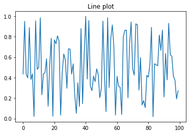

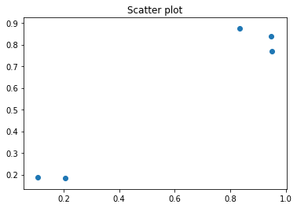

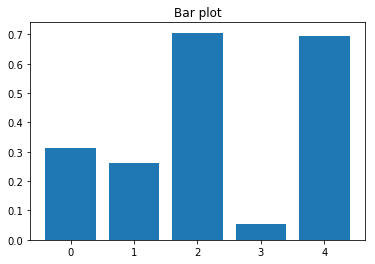

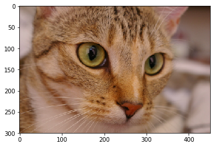

```python
import matplotlib.pyplot as plt
%matplotlib inline

plt.plot(df_for_line)
plt.title('Line plot')
plt.figure()

plt.scatter(df_for_scatter.col1, df_for_scatter.col2)
plt.title('Scatter plot')
plt.figure()

plt.bar(df_for_bar.index, df_for_bar.col1)
plt.title('Bar plot')
plt.figure()

from skimage import data

plt.imshow(data.chelsea())
```

# FAQs

- **How should I search when I am stuck?**
  - You can use google with specific keywords. For example, if you are doing some table processing using `pandas`, you should include `pandas` in keyword instead of `python`.
- **What sources from search results should I set higher priority to check out?**
  - This can be various, but first top focus should include **StackOverflow**, **GitHub**, and official sites of Python or packages in question.

# Mini challenge

- Click here to open mini challenge notebook.

# Assignment

- Click here to open assignment notebook.

# Learning Materials

- [Official Python tutorial](https://docs.python.org/3/tutorial/)
- [Chula's Python 101](https://www.cp.eng.chula.ac.th/books/python101/)